# Capstone assignment

2017-11-20

Data Analysis Using R - November 2017

## Capstone definition

- A coping stone :coping
- The high point :crowning achievement

"..the capstone of her career.."

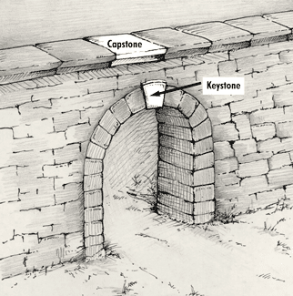

## Capstone in this course

- A showcase that you've learned how to use R in *every* element of the data cycle
- No statistical analysis
- Focus on read, clean and explore data
- Final product: An *.Rmd (and corresponding rendered *.html) file with your analysis sent to me by email **BEFORE** the deadline.

## Practical aspects

- Deadline 2 February 23:59 hrs., 2018
- Use this presentation-file "./capstone/capstone_assignment" to make the assignment
- Questions by email, and face-to-face by appointment only (tutor-slots)
- Work in pairs, explain your code to each-other, discuss steps you made, integrate you work in one analysis document

## The data

- `Toxcast`
- `US Airpollution`
- `Predict molecular properties`
- Or your data from your minor-project

Choose one of the datasets below

## Toxcast data

Difficulty: **

- Toxcast dataset in the folder "./capstone/data/toxcast"

## Online, open dataset 1: "US air pollution"

Difficulty: **

- https://www.kaggle.com/sogun3/uspollution
- The data for this dataset are in "./capstone/data/uspollution"

## Online, open dataset 2: "predicting molecular properties"

- If you choose this, you can get the data by a download link: https://www.kaggle.com/burakhmmtgl/predict-molecular-properties/downloads/predict-molecular-properties.zip (due to the big size of the file)

Difficulty: ***

```r
library(jsonlite)
file_json <- file.path(root, "capstone", "data", "predictmolprop", "pubChem_p_00000001_00025000.json")
example <- fromJSON(file_json, flatten=TRUE)
example$atoms[[1]]
```

## Your own data; prerequisites

- Quantitative data
- At least three factor (grouping) variables
- At least three different treatments
- At least 200 rows of raw data

*Sent an example to me, I will grade the difficulty and approve/disapprove the dataset.*

## The assignment

## Introduction

Write a short (max 300 words) introduction that explains some of the details of the data you are analyzing for your capstone assignment

- The type of data
- The 'experiment' or variables
- The source of the data
- The anticipated results or aim of the analysis: Which (research) question is being addressed

## Reading data into R

- Import the data into R with a code-chunk
- If zipped unzip the data with R before loading
- User `relative` paths so that your code is portable

## Inspect the integrity of the data

- Write a code chunk that checks the data, number of rows, number of variables, names of the variables, data-type of the variable
- Create a summary statistics of each variable that shows confidence intervals, max, min, mean, median values
- Create code that asserts the data-type of each variable

## Tidy data

- Write a code chunk that creates a tidy dataframe:
- Each variable in it's own column (long format)
- Each row has it's own observation
- Each value has it's own cell
- Variable names are all lowercase and snake_case and have a short descriptive name
- Reshape the data if necessary

## Select, Filter, Mutate, Summarize

- Select proper variables
- Filter values if needed
- Create new variables with `dplyr::mutate()` if needed
- Summarize the data by grouping variables and calculate mean values

## Exploratory data analysis

Create at least four (4) graphs that show some sort of relationship between variables present in the data

**For example:**

- Use colours to isolate groups in the data
- Use facets to show groups in the data
- Use diffrent types of graphs (e.g. `geom_point`, `geom_line`, `geom_bar`, `scale_fille_gradient` )
- Provide a graph that indicates information on the distribution of your data

## Graph criteria

- The graph has a descriptive title
- The axes have units and decriptive *short* titles
- The graph is visually appealing and the scale is correct

## Results

- Write a short paragraph (max 500 words) on your resulting graphs.
- What does the reader have to take away from the graphs you've shown?

*Tell a data-story!*

## Conclusion

- Refer to the introduction and write a short (max 200 words) conclusion on you analysis - Identify gaps in you analysis
- What still needs to be done? / What is lacking?